# Reviewer expertise and engagement in grant peer review

2nd Canadian Open Science Conference – pre-conference webinar

Sam Harper and Arijit Nandi

2026-10-02

# Grant peer review is suboptimal

## CIHR Project Grant review process

**1. Three assigned reviewers read and score**  
Assigned partly on self-declared expertise

**2. The committee discusses → consensus score**  
Reviewers present; all other members are “panelists”

**3. Every member then scores privately**  
Final scores must stay within ±0.5 of consensus

Our interest  
is here →→→

CIHR Project Grant Peer Review Manual, cihr-irsc.gc.ca/e/49564.html

## The context

**Scores decide who gets funded**  
Peer review moves billions of research dollars

**Scores come from humans in conversation**  
Panel discussion can change what reviewers think

**Engagement and expertise are differential**  
Some members read the application closely; most did not

## Prior literature

**Reliability is low**  
Inter-rater agreement is moderate-to-low

**Equity concerns are longstanding**  
Evidence of disadvantage by gender, race/ethnicity, and career stage in how panels score applications

**Discussion is rarely studied**  
“Strategic rating” and discussion dynamics can *worsen* inconsistencies and lead to bias

Thorngate, Dawes, and Foddy (2011); Tamblyn et al. (2018); Derrick and Samuel (2017); Witteman et al. (2019); Ginther et al. (2011); Guthrie, Ghiga, and Wooding (2018); Pier et al. (2017); Fogelholm et al. (2012)

Ch: Other comments? (pause) So with that, let’s hear our new scores?  
MP: So I’ll move to a four.  
Ch: Secondary?  
CV: Uh, I’ll move to a four also.  
Ch: Dr. Joshi?  
GJ: I had four to begin with and I’ll stay there.

Ch: Anyone outside that ra—these are pretty serious concerns that were raised. Four is a very high score.

JR: Yeah.  
CV: Yeah mine, actually go to a five.  
AA: (laughter)

Ch: Okay.  
GJ: I’ll go to five.  
MP: I’ll go to five.  
Ch: Let’s go again.

Pier et al. (2017), Figure 6

# Approach: Analyzing CIHR’s funding data

## Research questions

**Aim 1: Expertise and engagement**  
Do reviewers vs. panelists, and high vs. low expertise, differ in how they deviate from consensus?

**Aim 2: Whose scores move?**  
Do those patterns differ by applicant characteristics?

**Aim 3: What if?**  
Exploring alternatives (weighting by engagement, partial randomization).

## Elements of CIHR’s funding analytics database

| Indicator | Availability |
| --- | --- |
| Application | Application |
| Funding result | Extractable |
| Consensus score | Extractable |
| Resubmission status | Extractable (2023+) |
| Keywords / domain, # investigators, funding requested | In-house only |
| Applicant | Applicant |
| Prior funding success | Extractable |
| Gender, career stage | In-house only |
| Scientific productivity | To clarify |
| Member | Member |
| Role (reviewer vs. panelist) | Extractable |
| Self-declared expertise (High/Med/Low/Not enough) | Extractable |
| Final score, initial reviewer scores | Extractable |
| Prior funding success, conflicts of interest | Extractable |
| Gender | In-house only |
| Reviewer experience/tenure | To clarify |

Source: email from CIHR’s Funding Analytics Team, Dec. 4, 2025. “In-house only”: not shared as extracts (mainly identifiability risk), but a CIHR analyst can prepare the data and run our code in-house. “To clarify”: answered “unlikely” (scientific productivity) or “likely no, pending how we measure it” (reviewer experience).

## Approach: bring the code to the data

**Restricted application-level data**  
CIHR Funding Analytics holds it; we do not see identities

**Code must be submitted remotely**  
Analysts run it and return results (no interactive debugging)

**So we simulate first**  
Build, test, and pre-specify the whole pipeline on synthetic data

## The simulated world

**50** committees, **20-80** applications per committee

**8-37** committee members

**3** assigned reviewers, **15-16** applications discussed

Scores from truncated normal distribution

Modest treatment effects:

- **5pp** difference in deviation by engagement or expertise

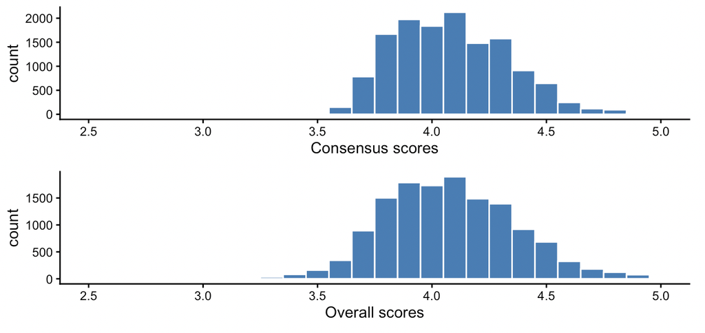

Outcome: $d_{ijk}$ = final score − consensus score

Committee size/workload: CIHR Fall 2025 Project Grant committee rosters, cihr-irsc.gc.ca/e/54732.html; application pool range: CIHR’s own stated 20-80 applications per committee

## A two-part model for a “spike and slab” outcome

Outcome: $d_{ijk}$ = final score − consensus score

Most likely adopt the consensus ($d = 0$)

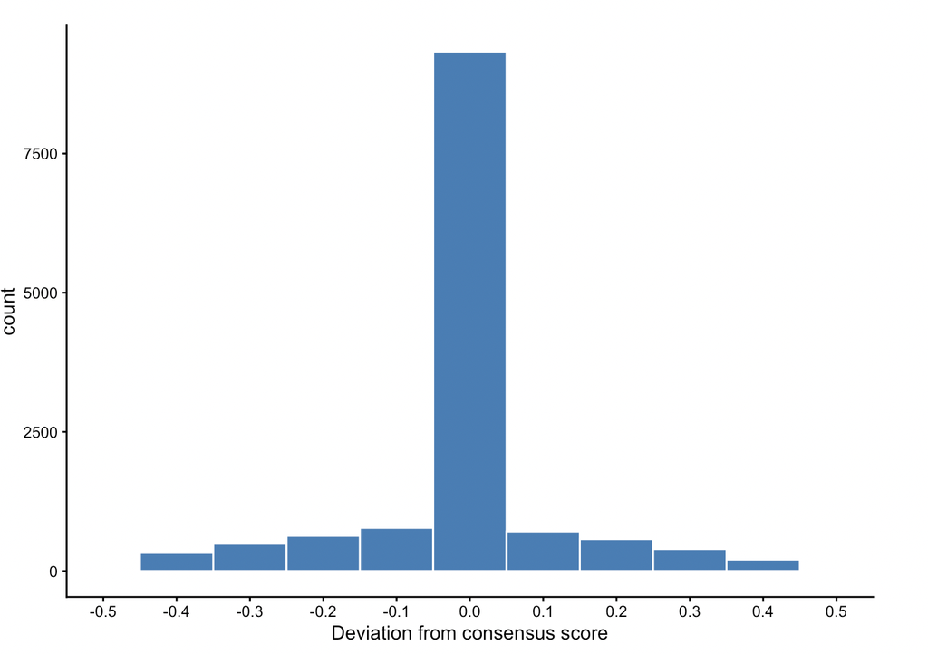

**Part 1:** did they deviate at all?

**Part 2:** by how much, and in which direction, if they did?

$$E[d] = \underbrace{P(\text{deviate})}_{\text{Part 1: Bernoulli}} \times \underbrace{E[d \mid \text{deviate}]}_{\text{Part 2: ordinal}}$$

Bayesian multilevel models with committee, application and member effects

Both parts allow **role** and **expertise** to shift the *location* and, in Part 2, the *spread*

## CIHR is actively reconsidering its own process

**Strengthening peer review**  
Need to improve the quality of panel discussions and reduce burden

**Process strain**  
Application volume up ~50% since 2023; Half of invited reviewers decline

**Community frustrations**  
Concerns about reviewer workload and turnover, frustrations with virtual meetings

“Strengthening peer review together,” CIHR, 2026-03-16, cihr-irsc.gc.ca/e/54669.html

## Why dedicated metaresearch funding matters

**Access**  
Partnership with the funder itself makes evaluating the funder’s own process possible

**Time to do it properly**  
Simulation, pre-specification and open code are slow and rarely rewarded in project grants

**Open science with sensitive data**  
A reusable template for “open code, closed data” evaluation

## Thank you

**Sam Harper** – McGill University  
`sbh4th@gmail.com`

**Funded by**  
Research on Research Joint Initiative: SSHRC, CIHR, Michael Smith Health Research BC

## References

Derrick, Gemma, and Gabrielle Samuel. 2017. “The Future of Societal Impact Assessment Using Peer Review: Pre-Evaluation Training, Consensus Building and Inter-Reviewer Reliability.” *Palgrave Communications* 3 (1): 17040. https://doi.org/10.1057/palcomms.2017.40.

Fogelholm, Mikael, Saara Leppinen, Anssi Auvinen, Jani Raitanen, Anu Nuutinen, and Kalervo Väänänen. 2012. “Panel Discussion Does Not Improve Reliability of Peer Review for Medical Research Grant Proposals.” *Journal of Clinical Epidemiology* 65 (1): 47–52. https://doi.org/10.1016/j.jclinepi.2011.05.001.

Ginther, Donna K., Walter T. Schaffer, Joshua Schnell, Beth Masimore, Faye Liu, Laurel L. Haak, and Raynard Kington. 2011. “Race, Ethnicity, and NIH Research Awards.” *Science* 333 (6045): 1015–19. https://doi.org/10.1126/science.1196783.

Guthrie, Susan, Ioana Ghiga, and Steven Wooding. 2018. “What Do We Know about Grant Peer Review in the Health Sciences? An Updated Review of the Literature and Six Case Studies.” RAND Corporation.

Johnson, Valen E. 2008. “Statistical Analysis of the National Institutes of Health Peer Review System.” *Proceedings of the National Academy of Sciences* 105 (32): 11076–80. https://doi.org/10.1073/pnas.0804538105.

Pier, Elizabeth L., Joshua Raclaw, Anna Kaatz, Markus Brauer, Molly Carnes, Mitchell J. Nathan, and Cecilia E. Ford. 2017. “‘Your Comments Are Meaner Than Your Score’: Score Calibration Talk Influences Intra- and Inter-Panel Variability During Scientific Grant Peer Review.” *Research Evaluation* 26 (1): 1–14. https://doi.org/10.1093/reseval/rvw025.

Tamblyn, Robyn, Nadyne Girard, Christina J. Qian, and James Hanley. 2018. “Assessment of Potential Bias in Research Grant Peer Review in Canada.” *Canadian Medical Association Journal* 190 (16): E489–99. https://doi.org/10.1503/cmaj.170901.

Thorngate, Warren, Robyn M. Dawes, and Margaret Foddy. 2011. *Judging Merit*. Hoboken: Taylor and Francis.

Witteman, Holly O, Michael Hendricks, Sharon Straus, and Cara Tannenbaum. 2019. “Are Gender Gaps Due to Evaluations of the Applicant or the Science? A Natural Experiment at a National Funding Agency.” *The Lancet* 393 (10171): 531–40. https://doi.org/10.1016/S0140-6736(18)32611-4.